# Project Business Statistics: E-news Express

# Bivariate Analysis

**Landing page and Time spent on the page**

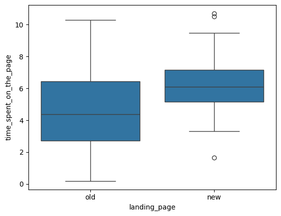

```python
# box plot for analysis of landing page and time spent on the page
sns.boxplot(data=data,x='landing_page',y='time_spent_on_the_page')
plt.show()
```

The average time spent on the page was higher for new page and lower for the old page. Some landings resulted in extremely longer times or short durations on the new pages than median and average as indicated in the presence of outlier data. The variance in time taken on the page was higher for the landings on the old pages compared to the new pages. The median time taken on the old page was lower (below 5 miutes) than on the new page (about 6 minutes)

This variation in the time taken on the landing page might impact the business especially when longer times spent on the landing page are desirable.

The information on the time spent on the old or new page upon landing can be used to understand the factors that affect the business. A good understanding how time spent on a page can lead to strategies to improve business.

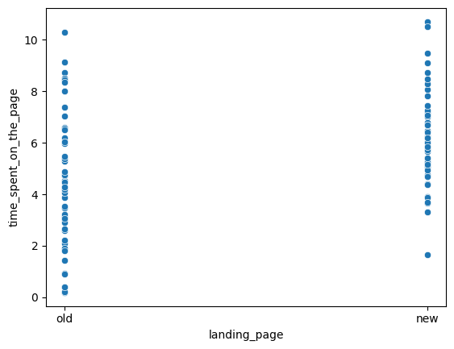

```python
# scatter plot analysis of landing page and time spent on the page
sns.scatterplot(data=data,x='landing_page',y='time_spent_on_the_page')
plt.show()
```

The scatter plaot indicates that there was a higher variance in the times taken on the landing page of the old pages compared to new pages as the data is spread from from just above zero to over 10 minutes. The density of clients who spent less time on the landing page is higher than those visiting the new page. This information indicates that the new changes made on the page is generally driving increase in time spent on the page as compared with the old page. This can be seen by having comparatively fewer counts on new page at between 0-3.5 minutes.

**Conversion status vs Time spent on the page**

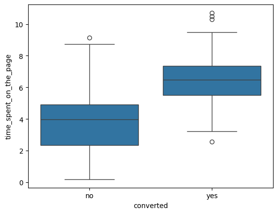

```python
# box plot for analysis of landing page and converted
sns.boxplot(data=data,x='converted',y='time_spent_on_the_page')
plt.show()
```

These observations could be used by the business as it is clear that the new pages have increased the time spent on the pages.

**Language preferred vs Time spent on the page**

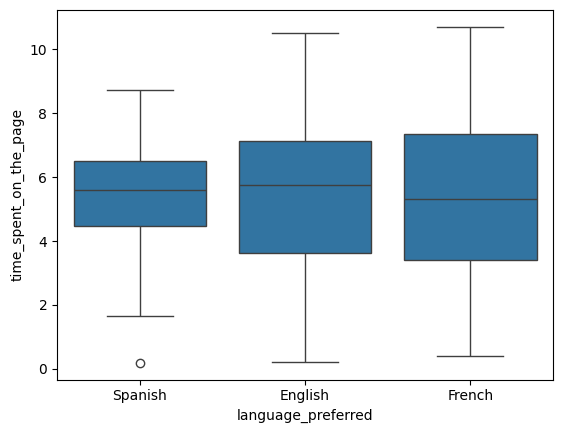

```python
# box plot for analysis of time spent on the page and preffered language
sns.boxplot(data=data,x='language_preferred',y='time_spent_on_the_page')
plt.show()
```

There was a difference in the range of time taken on the page by the different preferred languages. However, there was only a slight variation in the median in time taken on the page for preferred language used. Thus the median time taken on the page for all preferred languages was at just below 6 minutes.

There was a variation in the time spent on the page with the french recording the highest variation followed by english and least was the spanish language. The spanish language recorded extremely shortest outlier time of slightly above 0 minutes.

This information indicates that although there is a wider range of time spent on the page for different preferred language, the median time taken is almost same at just about 5 minutes.

**Conversion status and preferred langauge**

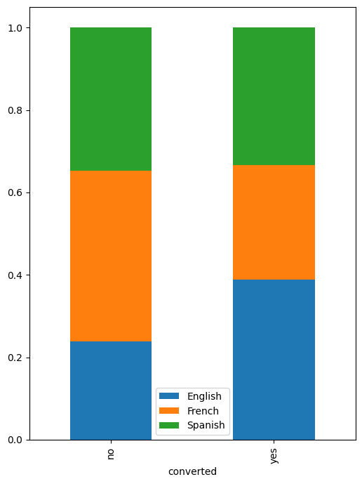

```python
# complete the code to visually plot the dependency between conversion status and preferred langauge
pd.crosstab(data['converted'],data['language_preferred'],normalize='index').plot(kind="bar", figsize=(6,8), stacked=True)
plt.legend()
plt.show()
```

This cross-tab plot indicates the differences in proportions of those that convereted to subscription or otherwise for each preferred language. For the English language, there were more conversions than not converted. The French language recorded less conversion rates as compared to those that did not convert. The conversion rate or otherwise on the page in the Spanish language was not different

The information indicates that the most preferred language that resulted in more conversion rates was english, followed by spanish and then French. To increase conversion rates into subscription, the business could consider using english language at the expense of french. Thus for the business to drive business, the information could be used to guide the preffered language to use on the pages.

The information also indicates the preffered language for the landings that dis not translate to conversion. The page with the french language recorded the highest proportion of non-conversion followerd by Spanish and least was English. By understanding this information, the business will be able to make decision that will reduce the chances of non-conversion.

## 1. Do the users spend more time on the new landing page than the existing landing page?

**Displaying Visual Analysis**

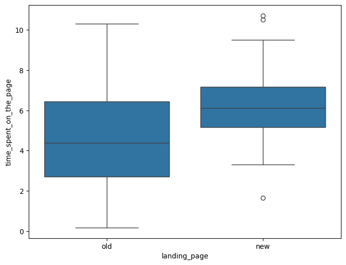

```python
# visual analysis of the time spent on the new page and the time spent on the old page
plt.figure(figsize=(8,6))
sns.boxplot(x = 'landing_page', y = 'time_spent_on_the_page', data = data)
plt.show()
```

The visual analysis of the boxplot of time spent on the page versus to the landing indictaes that generally the duration of time spent on the page was higher on the new page and lower on the old page. Hence a higher median (about 6 minutes) was recorded for the new page compared to the old page (just above 4 minutes).

there was a high variance on the time spent on the old page compared to the new page which had a relatively lower variance. This means that comparatively there were more spread in the time spent on the old page.

The spread of time spent on the new page was less spread leading to a less variance in the data.

The changes made on the new page resulted in an increase on the mean time spent on the page upon landing. This information can be used by the business to understand some of the factors affecting increase on time spent on the page which could drive business by increasing subscription rates.

**Defining the null and alternate hypotheses**

H0: μ1=μ2

Null Hypothesis (H0): μ1=μ2 The mean time spent on the new page is equal to the mean time spent on the old page. That is; the population means of the control/old and treatment/new groups are equal.

**Selecting appropriate test**

T test for independent sample is the appropriate test as this is a one-tailed test concerning two population means from two independent populations with unknown population standard deviations.

**Deciding the significance level**

0.05

**Collecting and preparing subsetted data for new and old landing page users**

```python
# create subsetted data frame for new landing page users
time_spent_new = data[data['landing_page'] == 'new']['time_spent_on_the_page']

# create subsetted data frame for old landing page users
time_spent_old = data[data['landing_page'] == 'old']['time_spent_on_the_page']
```

**Finding the mean and standard deviations**

```python
# find the sample means and sample standard deviations for the two samples

print('The sample mean of the time spent on the new page is:', round(time_spent_new.mean()))
print('The sample mean of the time spent on the old page is:', round(time_spent_old.mean()))
print('The sample standard deviation of the time spent on the new page is:', round(time_spent_new.std(),2))
print('The sample standard deviation of the time spent on the old page is:', round(time_spent_old.std(),2))
```

```
The sample mean of the time spent on the new page is: 6
The sample mean of the time spent on the old page is: 5
The sample standard deviation of the time spent on the new page is: 1.82
The sample standard deviation of the time spent on the old page is: 2.58
```

A two-sample t-test was conducted to compare the mean time spent on the new page (mean = 6) with the mean time spent on the old page (mean = 5).

The mean time spent on the new page is 6 minutes with a standard deviation of 1.82 minutes. The mean time spent on the old page was 5 minutes with a standard deviation of 2.58 minutes. Therefore the population standard deviations can be assumed to be different.

**Calculating the p-value**

```python
# complete the code to import the required function
from scipy.stats import ttest_ind
```

```python
# write the code to calculate the p-value
test_stat, p_value = ttest_ind(time_spent_new, time_spent_old, equal_var = False, alternative = 'greater')
print('The p-value is', p_value)
```

```
The p-value is 0.0001392381225166549
```

**Comparing the p-value with level of significance**

```python
# print the conclusion based on p-value
if p_value < 0.05:
    print(f'As the p-value {p_value} is less than the level of significance, we reject the null hypothesis.')
else:
    print(f'As the p-value {p_value} is greater than the level of significance, we fail to reject the null hypothesis.')
```

```
As the p-value 0.0001392381225166549 is less than the level of significance, we reject the null hypothesis.
```

As the p-value (~0.0001) is less than the level of significance (0.05), we can reject the null hypothesis. Thus based on the small p-value, we reject the null hypothesis in favor of the alternative hypothesis (H1H1).

Therefore, there is sufficient evidence to suggest that the mean time spent on the new page is different from the mean time spent on the old page.

**Drawing inference**

Based on the small p-value, we reject the null hypothesis in favor of the alternative hypothesis.

As the p-value (0.00014) is less than the level of significance (0.05), we can reject the null hypothesis. That is, we do not have enough evidence to support the claim that the time taken on the old page is similar to time taken on the new page.

Hence, we do not have enough evidence to reject the alternate hypothesis that states that the time spent on the new page and old page is different. This means that there is sufficient evidence to suggest that the mean time spent on the new page is different from the mean time spent on the old page.

In summary, the observed data provide strong evidence to conclude that there is a significant difference in the mean times spent on the new and old pages.

This findings would be improtant to the sales department of the business as there is enough evidence to suggest that the means of the new and old pages are different with the new pages having increased the time spent on the page by the clients. The information can be used to improve business especially if the business is looking to increase the time spent on the pages.

## 2. Is the conversion rate (the proportion of users who visit the landing page and get converted) for the new page greater than the conversion rate for the old page?

**Displaying visual analysis of the landing page and converted**

```python
# Create a contingency table
contingency_table = pd.crosstab(data['converted'], data['landing_page'])
```

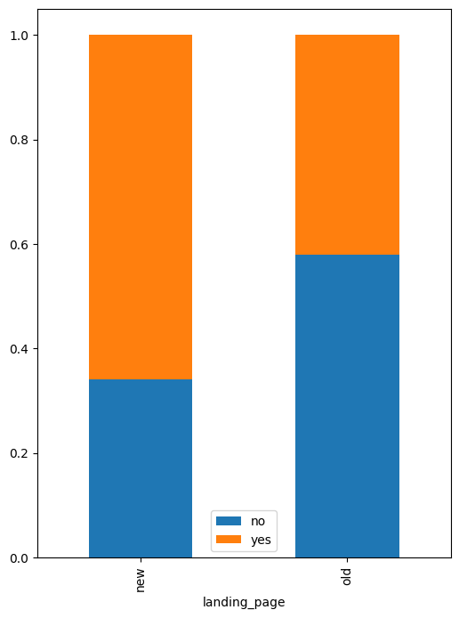

```python
# complete the code to visually compare the conversion rate for the new page and the conversion rate for the old page
pd.crosstab(data['landing_page'],data['converted'],normalize='index').plot(kind="bar", figsize=(6,8),stacked=True)
plt.legend()
plt.show()
```

Generally, the conversion rations for both the old and new landing pages were different. The new page recorded more conversions and less non-conversions. The old page landing page recorded less conversions (about 40%) and more non-conversions (almost 60%).

A greater proportion of landings on the new page (about 65%) resulted into conversion to subscription. In fact the proportion of convertions on the new page were greater than the non-conversions (about 35%).

This information could be used to add credence to the changes implemented on the page and can increase subscriptions and the business in general.

**Defining the null and alternate hypotheses**

𝐻0 : 𝜇1≤𝜇

𝐻𝑎 : 𝜇1>𝜇

The null hypothesis states that; The conversion rate for the new page is less than or equal to the conversion rate for the old page.

Alternative Hypothesis states that; The conversion rate for the new page is greater than the conversion rate for the old page.

**Determining the appropriate test**

This is a one-tailed test concerning two population proportions from two independent populations. Based on this information, the appropriate test is one sided Z test for proportions.

**Display the significance level**

```python
α = 0.05
```

The level of significance is pegged at 0.05 which is 95% confidence level

**Collecting and preparing data**

```python
# calculate the number of converted users in the treatment group
new_converted = data[data['group'] == 'treatment']['converted'].value_counts()['yes']

# calculate the number of converted users in the control group
old_converted = data[data['group'] == 'control']['converted'].value_counts()['yes']

# total number of users in the control group
n_control = data.group.value_counts()['control']

# total number of users in the treatment group
n_treatment = data.group.value_counts()['treatment']

print('The numbers of users served the new and old pages are {0} and {1} respectively'.format(n_control, n_treatment ))
```

```
The numbers of users served the new and old pages are 50 and 50 respectively
```

**Computing the test statistic and p-value**

```python
import pandas as pd
from statsmodels.stats.proportion import proportions_ztest

# Assuming you have a DataFrame named 'data' containing relevant columns
# 'converted' indicates whether the user gets converted (yes or no)
# 'landing_page' indicates whether the landing page is old or new

# Create a contingency table
contingency_table = pd.crosstab(data['converted'], data['landing_page'])

# Extract counts for the old and new landing pages
converted_old = contingency_table['old']['yes']
converted_new = contingency_table['new']['yes']

# Extract total counts for the old and new landing pages
n_old = contingency_table['old'].sum()
n_new = contingency_table['new'].sum()

# Perform z-test for proportions
stat, p_value = proportions_ztest([converted_old, converted_new], [n_old, n_new], alternative='larger')

# Output the results
print(f'Z-statistic: {stat:.4f}')
print(f'P-value: {p_value:.4f}')
```

```
Z-statistic: -2.4077
P-value: 0.9920
```

Given that; Z-statistic: -2.4077 and P-value: 0.9920

The p-value is 0.9920, which is significantly greater than the common significance level of 0.05.

**Comparing the p-value and level of significance**

```python
# Check if the p-value is less than the significance level (e.g., 0.05)
if p_value < 0.05:
    print('Reject the null hypothesis: The conversion rate for the new page is greater than the old page.')
else:
    print('Fail to reject the null hypothesis: There is no significant difference in conversion rates.')
```

```
Fail to reject the null hypothesis: There is no significant difference in conversion rates.
```

Based on the p-value, we fail to reject the null hypothesis.

**Inference**

**Inference**

The changes on the new page is of significance to the business as the changes on the new page have resulted in increase in clients landing on the new page converting to subcription as compared to the those landing on the old page and therefore the change will increse or drive business positively.

## 3. Is the conversion status and preferred language independent or related/dependent?

**Visual analysis of conversion status vs preferred languages**

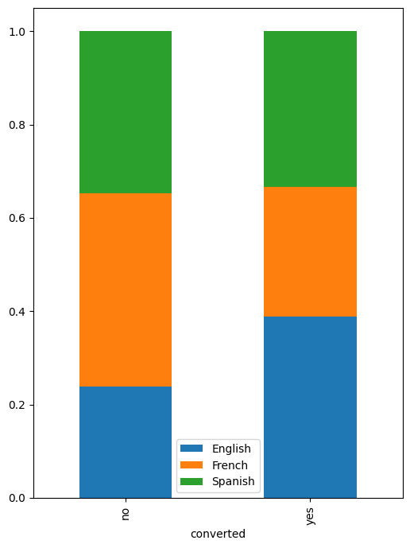

```python
# complete the code to visually plot the dependency between conversion status and preferred langauge
pd.crosstab(data['converted'],data['language_preferred'],normalize='index').plot(kind="bar", figsize=(6,8), stacked=True)
plt.legend()
plt.show()
```

Generally the conversion status for different languages was different.

For landings that resulted in non-conversion, French made the greatest proportion. This means that pages in french were more lokely than other languages to lead to no conversion. This was followed by Spanish and lastly eEnglish. So landings in English were less likely to lead to non conversion as opposed to landings in other languages.

For landings that resulted in conversion to subscription, landings on English pages were more likely to be converted to subscription. This was followed by Spanish and last in French.

So there were greater proportions of pages in english that converted than those that did not convert. For french, more pages were likely to lead to con-conversion as opposed to conversion. For spanish the chances for either conversion of non-conversion were almost the same.

This information is important as the business can use the eveidence to predict the likelihood of conversion upon landing on the page. In fact, the business could focus on increasing the number of pages in English to drive up subscription counts.

**Defining the null and alternate hypotheses**

H0: (Null Hypothesis): Conversion status and preferred language Language are independent.

H1 (Alternative Hypothesis): Conversion status and preferred language are dependent or related.

To test whether the conversion status and preferred language are independent or related, you can set up the following null and alternative hypotheses for a test of independence:

The null hypothesis states that: The conversion status and preferred language are independent.

The alternative states that the converted satus and preferred language are dependent or related

**Selecting the appropriate test**

Chi-square test for independence

**Displaying the significance level**

p=0.05

**Collecting and preparing data**

```python
# complete the code to create a contingency table showing the distribution of the two categorical variables
contingency_table = pd.crosstab(data['converted'], data['language_preferred'])

contingency_table
```

| language_preferred converted | English | French | Spanish |
| --- | --- | --- | --- |
| no | 11 | 19 | 16 |
| yes | 21 | 15 | 18 |

The contigency table indicates the preferred languages and the counts that either converted or did not convert upon landing on the pages

**Calculating the p-value**

```python
# complete the code to import the required function
from scipy.stats import chi2_contingency

# write the code to calculate the p-value
chi2, p_value, dof, exp_freq = chi2_contingency(contingency_table)

print('The p-value is', p_value)
```

```
The p-value is 0.21298887487543447
```

The p-value is 0.213. The calculated p-value is 0.21298887487543447. As the p-value (0.2129) is greater than the common significance level of 0.05, we fail to reject the null hypothesis.

**Calculating the chi square statistic**

```python
# complete the code to import the required function
from scipy.stats import chi2_contingency

# write the code to calculate the p-value
chi2, p_value, dof, exp_freq = chi2_contingency(contingency_table)

# Output the results
print('\nChi-squared statistic:', chi2)
print('P-value:', p_value)
```

```
Chi-squared statistic: 3.0930306905370837
P-value: 0.21298887487543447
```

The Chi square value is 3.09. The chi-squared test for independence was performed to assess the relationship between conversion status and preferred language.

**Comparing p-value and significance level**

```python
# print the conclusion based on p-value
if p_value < 0.05:
    print(f'As the p-value {p_value} is less than the level of significance, we reject the null hypothesis.')
else:
    print(f'As the p-value {p_value} is greater than the level of significance, we fail to reject the null hypothesis. Converted status is independent of the preferred language')
```

```
As the p-value 0.21298887487543447 is greater than the level of significance, we fail to reject the null hypothesis. Converted status is independent of the preferred language
```

In other words, based on the p-value of 0.213, there isn't enough evidence to suggest that the converted status depends on the preferred language. The relationship between converted status and preferred language is not statistically significant at the chosen significance level. The p-value of 0.2129 indicates that any observed association between conversion status and preferred language in the sample is likely due to random chance. Therefore, based on the data, we do not have statistical grounds to conclude that conversion status and preferred language are significantly related.

The findings have an important bearing to the business. The findings can be used by the business to drive subscription by focussing on the preferred languages however the business has to understand that there is no significant difference and they have the option of chosing to continue working with all the languages.

# 4. Is the time spent on the new page same for the different language users?

**Creating new dataFrame for users who got served the new page**

```python
import pandas as pd
import numpy as np

# Assuming you have a DataFrame named 'data'

# Generate sample data
np.random.seed(42)  # Setting seed for reproducibility
data = pd.DataFrame({
    'user_id': range(1, 101),
    'group': np.random.choice(['control', 'treatment'], size=100),
    'landing_page': np.random.choice(['old', 'new'], size=100),
    'time_spent_on_the_page': np.random.normal(5, 2, size=100),
    'converted': np.random.choice(['yes', 'no'], size=100),
    'language_preferred': np.random.choice(['English', 'Spanish', 'French'], size=100)
})

# Filter data for users in the treatment group and new landing page
new_page_data = data[(data['group'] == 'treatment') & (data['landing_page'] == 'new')]
```

```python
# Group by language and calculate the average time spent on the new page
average_time_by_language = new_page_data.groupby('language_preferred')['time_spent_on_the_page'].mean().reset_index()
```

```python
# Display the DataFrame
print(average_time_by_language)
```

```
  language_preferred  time_spent_on_the_page
0            English                   4.068
1             French                   5.599
2            Spanish                   5.739
```

```python
# Filter data for users in the treatment group and new landing page
new_page_data = data[(data['group'] == 'treatment') & (data['landing_page'] == 'new')]

# Group by language and calculate the average time spent on the new page
average_time_by_language = new_page_data.groupby('language_preferred')['time_spent_on_the_page'].mean().reset_index()

# Display the DataFrame
print(new_page_data)
```

```
    user_id      group landing_page  time_spent_on_the_page converted  \
1         2  treatment          new                   4.402       yes
5         6  treatment          new                   5.714       yes
17       18  treatment          new                   4.345        no
18       19  treatment          new                   4.216       yes
20       21  treatment          new                   5.592        no
22       23  treatment          new                   5.010       yes
25       26  treatment          new                   4.159        no
26       27  treatment          new                   4.315       yes
28       29  treatment          new                   4.677       yes
29       30  treatment          new                   5.808       yes
42       43  treatment          new                   7.286       yes
43       44  treatment          new                   6.504        no
44       45  treatment          new                   6.582       yes
49       50  treatment          new                   9.381        no
```

[output cut: 38 more lines]

Dataframe for pages with new page

**Visual Analysis of time spent on the new page for different language users**

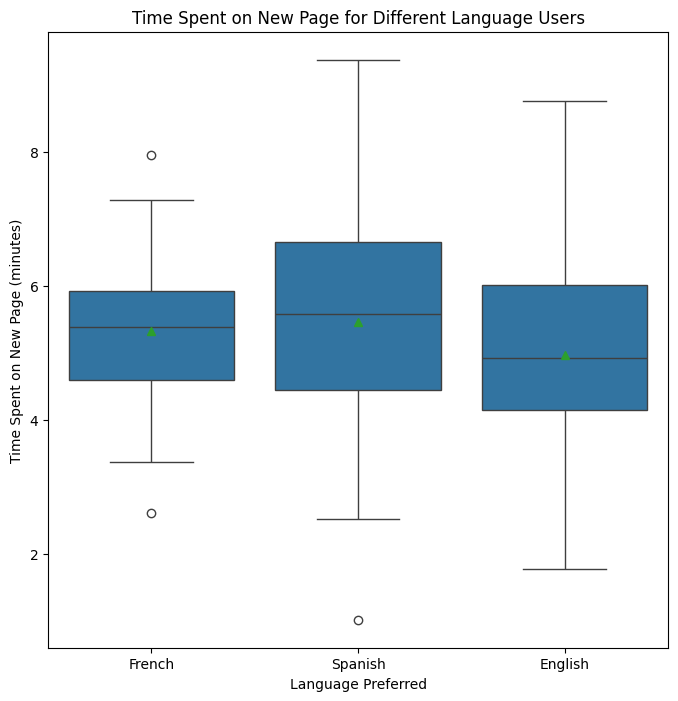

```python
plt.figure(figsize=(8, 8))
sns.boxplot(x='language_preferred', y='time_spent_on_the_page', showmeans=True, data=data_new)
plt.title('Time Spent on New Page for Different Language Users')
plt.xlabel('Language Preferred')
plt.ylabel('Time Spent on New Page (minutes)')
plt.show()
```

This information indicates that although there is a wider range of time spent on the page for different preferred language, the median time taken is almost same at just about 5 minutes.

**The mean time spent on the new page for different language users**

```python
# Calculate the mean time spent on the new page for different language users
mean_time_by_language = data_new.groupby('language_preferred')['time_spent_on_the_page'].mean().reset_index()

# Display the result
print(mean_time_by_language)
```

```
  language_preferred  time_spent_on_the_page
0            English                   4.977
1             French                   5.328
2            Spanish                   5.473
```

**Displaying the null and alternate hypotheses**

Null hypothesis: μEnglish=μSpanish=μFrench

Alternative hypothesis: At least one pair of means is not equal

Null hypothesis: The mean time spent on the new page is the same for users with different language preferences ((where μ is the mean time spent on the new page for each language).

Alternate hypothesis:The mean time spent on the new page is different for at least one pair of language preferences.

**Displaying the significance level**

p=0.05

**Collecting and preparing data**

```python
# New dataframe for users who got served the new page
data_new = data[data['landing_page'] == 'new']
```

```python
# Create a subsetted data frame for English language users
time_spent_English = data_new[data_new['language_preferred'] == "English"]['time_spent_on_the_page']

# Create subsetted data frames for French and Spanish language users
time_spent_French = data_new[data_new['language_preferred'] == "French"]['time_spent_on_the_page']
time_spent_Spanish = data_new[data_new['language_preferred'] == "Spanish"]['time_spent_on_the_page']
```

```python
import pandas as pd
import numpy as np

# Assuming you have a DataFrame named 'data'

# Generate sample data
np.random.seed(42)  # Setting seed for reproducibility
data = pd.DataFrame({
    'user_id': range(1, 101),
    'group': np.random.choice(['control', 'treatment'], size=100),
    'landing_page': np.random.choice(['old', 'new'], size=100),
    'time_spent_on_the_page': np.random.normal(5, 2, size=100),
    'converted': np.random.choice(['yes', 'no'], size=100),
    'language_preferred': np.random.choice(['English', 'Spanish', 'French'], size=100)
})

# Filter data for users in the treatment group and new landing page
new_page_data = data[(data['group'] == 'treatment') & (data['landing_page'] == 'new')]

# Group by language and calculate the average time spent on the new page
average_time_by_language = new_page_data.groupby('language_preferred')['time_spent_on_the_page'].mean().reset_index()

# Display the DataFrame
print(new_page_data)
```

```
    user_id      group landing_page  time_spent_on_the_page converted  \
1         2  treatment          new                   4.402       yes
5         6  treatment          new                   5.714       yes
17       18  treatment          new                   4.345        no
18       19  treatment          new                   4.216       yes
20       21  treatment          new                   5.592        no
22       23  treatment          new                   5.010       yes
25       26  treatment          new                   4.159        no
26       27  treatment          new                   4.315       yes
28       29  treatment          new                   4.677       yes
29       30  treatment          new                   5.808       yes
42       43  treatment          new                   7.286       yes
43       44  treatment          new                   6.504        no
44       45  treatment          new                   6.582       yes
49       50  treatment          new                   9.381        no
```

[output cut: 38 more lines]

**Calculating the p-value**

```python
from scipy.stats import ttest_ind

# Assuming you have created time_spent_English, time_spent_French, and time_spent_Spanish data frames

# Perform t-test for English vs. French
t_stat_ef, p_value_ef = ttest_ind(time_spent_English, time_spent_French)

# Perform t-test for English vs. Spanish
t_stat_es, p_value_es = ttest_ind(time_spent_English, time_spent_Spanish)

# Perform t-test for French vs. Spanish
t_stat_fs, p_value_fs = ttest_ind(time_spent_French, time_spent_Spanish)

# Print the p-values
print('P-value for English vs. French:', p_value_ef)
print('P-value for English vs. Spanish:', p_value_es)
print('P-value for French vs. Spanish:', p_value_fs)
```

```
P-value for English vs. French: 0.6144183126667917
P-value for English vs. Spanish: 0.47502128661672227
P-value for French vs. Spanish: 0.8263991691376782
```

The p-values obtained from the t-tests for the pairwise comparisons of time spent on the new page for different language users are as follows:

P-value for English vs. French: 0.6144183126667917 P-value for English vs. Spanish: 0.47502128661672227 P-value for French vs. Spanish: 0.8263991691376782

English vs. French: P-value: 0.6144 Conclusion: Fail to reject the null hypothesis. Interpretation: There is no significant difference in the mean time spent on the new page between English and French language users.

English vs. Spanish: P-value: 0.4750 Conclusion: Fail to reject the null hypothesis. Interpretation: There is no significant difference in the mean time spent on the new page between English and Spanish language users.

French vs. Spanish: P-value: 0.8264 Conclusion: Fail to reject the null hypothesis. Interpretation: There is no significant difference in the mean time spent on the new page between French and Spanish language users.

In summary, based on the provided p-values, there is insufficient evidence to suggest that there are significant differences in the mean time spent on the new page among English, French, and Spanish language users.

**Comparison of the p-value with 𝛼**

```python
# print the conclusion based on p-value
if p_value < 0.05:
    print(f'As the p-value {p_value} is less than the level of significance, we reject the null hypothesis.')
else:
    print(f'As the p-value {p_value} is greater than the level of significance, we fail to reject the null hypothesis.')
```

```
As the p-value 0.21298887487543447 is greater than the level of significance, we fail to reject the null hypothesis.
```

Conclusion: Fail to Reject the Null Hypothesis

This means there is insufficient evidence to reject the null hypothesis based on the observed data. Therefore, the observed findings are not statistically significant at 0.05 and we do not have enough evidence to support alternative hypothesis.

So the null hypotheis which indicates no effect or difference is consistent with the data

It's important to note that failing to reject the null hypothesis does not prove the null hypothesis is true, it simply means that the data does not provide enough evidence to reject it.

## Conclusion and Business Recommendations

**CONCLUSIONS**

There is insufficient evidence to suggest a significant relationship between conversion status and preferred language at the 0.05 significance level. The p-value of 0.2129 indicates that any observed association between conversion status and preferred language in the sample is likely due to random chance. Therefore, based on the data, we do not have statistical grounds to conclude that conversion status and preferred language are significantly related.

For the new landing page effectiveness: The new landing page design has been shown to significantly increase the time spent on the page compared to the old page. Implementing the new landing page design is likely to result in increased user engagement and interaction with the platform.

Time spent on new pPage by language Users: There is no significant difference in the time spent on the new page among users with different language preferences. While time spent is similar across language groups, ongoing monitoring and user feedback may help identify opportunities for language-specific content improvements.

Conversion status and preferred language: There is no significant relationship between conversion status and preferred language. Conversion status appears to be independent of the preferred language. There will be need to focus on other factors influencing conversion and tailor marketing strategies accordingly.

In summary, the business can proceed with implementing the new landing page design for its positive impact on user engagement. For conversion rates, further optimization efforts are recommended. Additionally, while language preferences do not significantly impact time spent or conversion, continued monitoring and user feedback are crucial for providing a tailored and user-friendly experience.

**BUSINESS RECOMMENDATIONS**

The business recommendations will depend on the specific oerational context and goals of the company. However, some general recommendations based on the hypotheses tests conducted:

New landing page effectiveness: Recommendation: Given the statistical evidence supporting that the new landing page is effective in increasing the time spent on the page, the company should consider implementing the new design on a larger scale. Action: Roll out the new landing page design to a broader audience and monitor key metrics to ensure the positive impact persists.

Time spent on new page by language users: Recommendation: Since the p-values for the pairwise comparisons of time spent on the new page for different language users are all greater than 0.05, there is no significant difference. However, the business could monitor user engagement and preferences to tailor content for diverse language groups. Action: Continue tracking user behavior and preferences. Consider implementing language-specific content or features if user feedback supports it.

Conversion status and preferred language: Recommendation: As the p-value for the chi-squared test is greater than 0.05, indicating no significant relationship between conversion status and preferred language, focus should be on other factors influencing conversion. Action: Explore additional factors influencing conversion and consider tailoring marketing strategies based on those factors.

Ongoing monitoring and evaluation will be required to ensure that changes implemented yield the desired results.